# Project

1. Read the data from the data set. Enlist the variables in the data set and display its structure. (Set the path in console to the directory where data set is present or specify full path of file)

```r
set <- read.delim("facebook.txt", header = TRUE,  sep = "\t")
names(set)
```

```
##  [1] "userid"                "age"
##  [3] "dob_day"               "dob_year"
##  [5] "dob_month"             "gender"
##  [7] "tenure"                "friend_count"
##  [9] "friendships_initiated" "likes"
## [11] "likes_received"        "mobile_likes"
## [13] "mobile_likes_received" "www_likes"
## [15] "www_likes_received"
```

```r
str(set)
```

```
## 'data.frame':    99003 obs. of  15 variables:
##  $ userid               : int  2094382 1192601 2083884 1203168 1733186 1524765 1136133 1680361 1365174 1712567 ...
##  $ age                  : int  14 14 14 14 14 14 13 13 13 13 ...
##  $ dob_day              : int  19 2 16 25 4 1 14 4 1 2 ...
##  $ dob_year             : int  1999 1999 1999 1999 1999 1999 2000 2000 2000 2000 ...
##  $ dob_month            : int  11 11 11 12 12 12 1 1 1 2 ...
##  $ gender               : Factor w/ 2 levels "female","male": 2 1 2 1 2 2 2 1 2 2 ...
##  $ tenure               : int  266 6 13 93 82 15 12 0 81 171 ...
##  $ friend_count         : int  0 0 0 0 0 0 0 0 0 0 ...
##  $ friendships_initiated: int  0 0 0 0 0 0 0 0 0 0 ...
##  $ likes                : int  0 0 0 0 0 0 0 0 0 0 ...
##  $ likes_received       : int  0 0 0 0 0 0 0 0 0 0 ...
##  $ mobile_likes         : int  0 0 0 0 0 0 0 0 0 0 ...
##  $ mobile_likes_received: int  0 0 0 0 0 0 0 0 0 0 ...
##  $ www_likes            : int  0 0 0 0 0 0 0 0 0 0 ...
##  $ www_likes_received   : int  0 0 0 0 0 0 0 0 0 0 ...
```

Install and load the library ggplot2.

```r
suppressWarnings(library(ggplot2))
```

2. We start by displaying the Birthday count of facebook users. Breaks represents the number of parts we want to divide our histogram into.

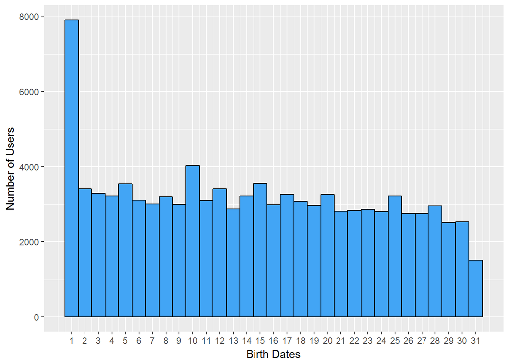

```r
qplot(x = dob_day, data = set, binwidth = 1,
     color = I('black'), fill = I('#42A5F5'),
     xlab = "Birth Dates", ylab = "Number of Users") +
  scale_x_continuous(breaks = seq(1, 31))
```

3. To make sense of the discrepancy of the tall bar on 1st of the month, we split the histogram into 12 histograms.

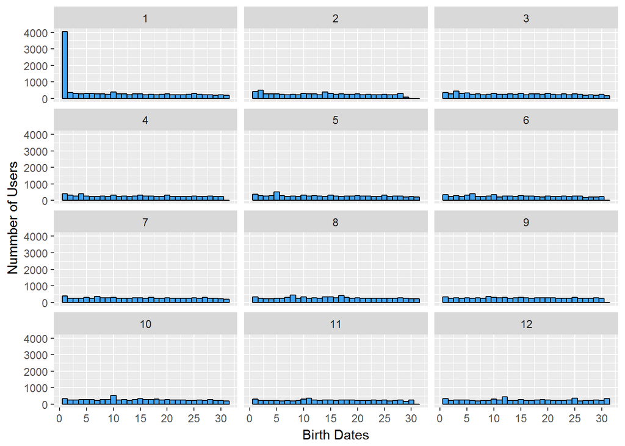

```r
qplot(x = dob_day, data = set, binwidth = 1,
     color = I('black'), fill = I('#42A5F5'),
     xlab = "Birth Dates", ylab = "Nummber of Users") +
  facet_wrap(~dob_month, ncol = 3) +
  scale_x_continuous(breaks = seq(0, 31, 5))
```

4.Next, we create a histogram of friend_count.

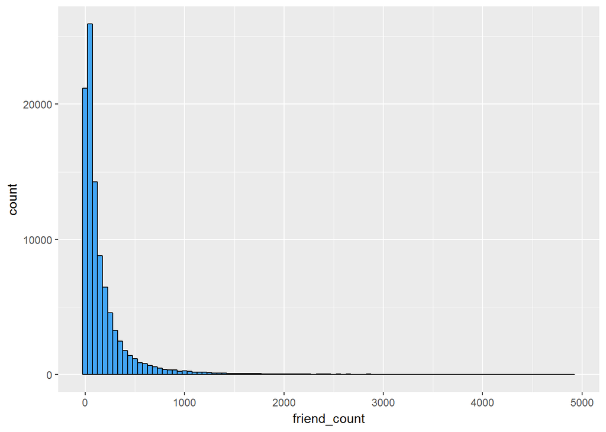

```r
qplot(x = friend_count, data = set, binwidth = 50,
    color = I('black'), fill = I('#42A5F5'))
```

5. We try to answer the question who has more friends on average - males or females. Hence we facet our histogram, based on gender.

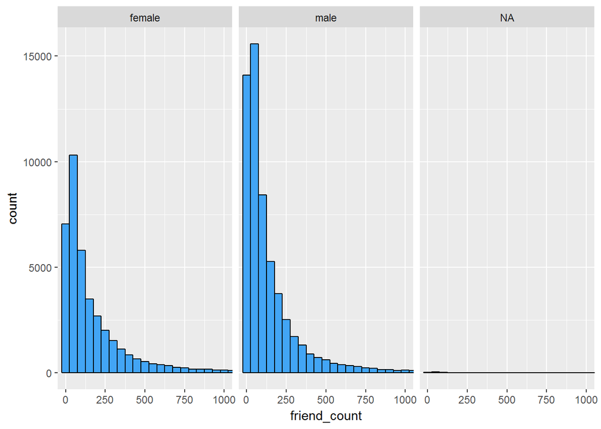

```r
qplot(x = friend_count, data = set, binwidth = 50,
    color = I('black'), fill = I('#42A5F5')) +
  facet_wrap(~gender) +
  coord_cartesian(xlim = c(0, 1000))
```

To eliminate the NA observations, we subset the data to exclude them.

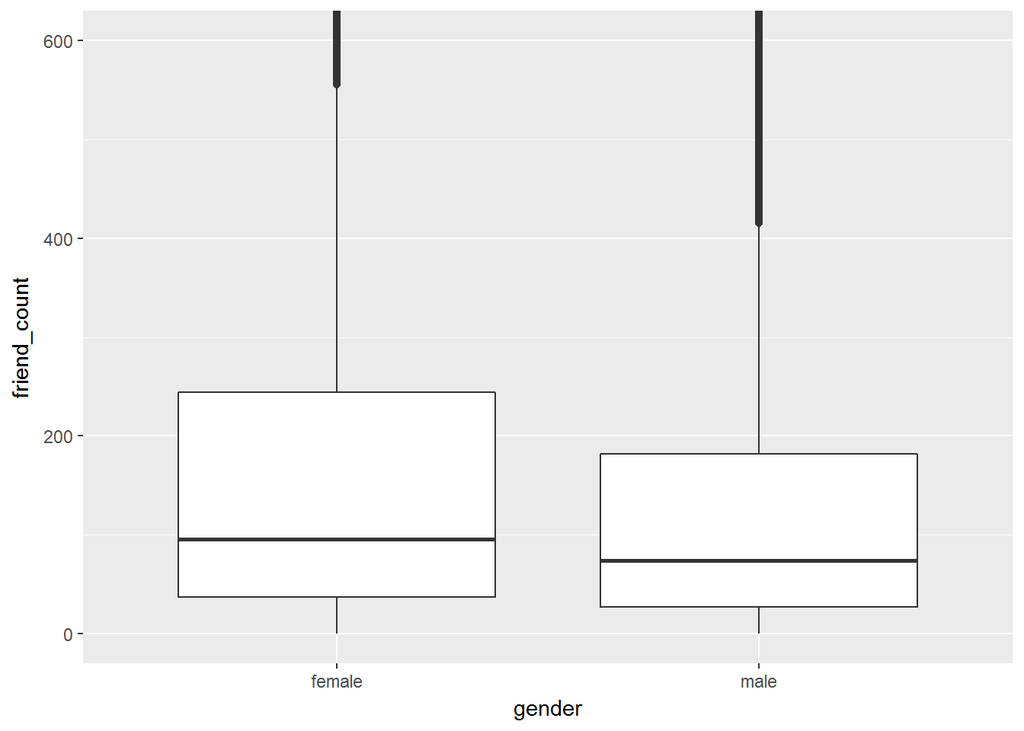

```r
qplot(y = friend_count, x = gender,  data = subset(set, !is.na(gender)), geom = 'boxplot') +
  coord_cartesian(ylim = c(0, 600))
```

We can observe that females have a higher median friend count than males. We create a frequency polygon to verify this.

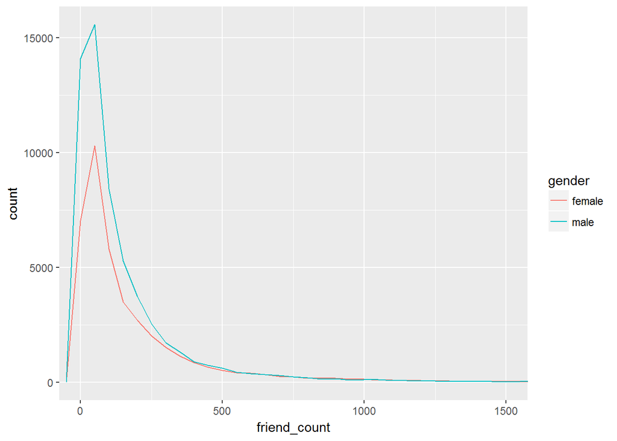

```r
qplot(x = friend_count, data = subset(set, !is.na(gender)), binwidth = 50,
      color = gender, geom = 'freqpoly') +
  coord_cartesian(xlim = c(0, 1500))
```

6. We try to answer the question ‘what is the relation between age and tenure?’

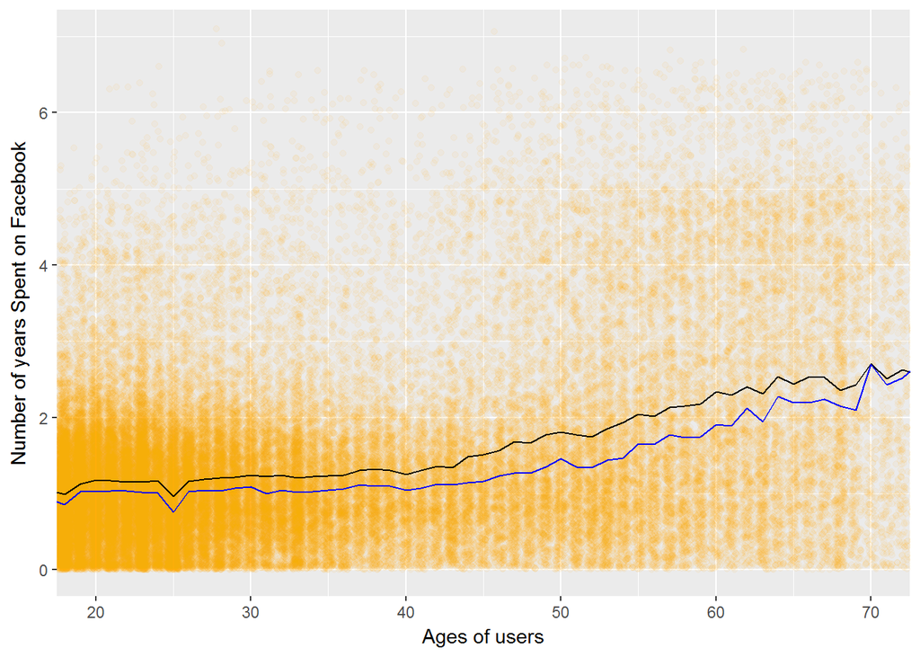

```r
ggplot(aes(y = tenure/365,  x = age), data = subset(set, !is.na(tenure))) +
  geom_point(alpha = 1/20, position = position_jitter(height = 0), color = I('orange')) +
  coord_cartesian(xlim = c(20, 70), ylim = c(0, 7)) +
  xlab("Ages of users") +
  ylab("Number of years Spent on Facebook") +
  geom_line(stat = 'summary', fun.y = mean) +
  geom_line(stat = 'summary', fun.y = median, color = I('blue'))
```

7. We will now see how the friendships initiated by people vary with their current friend count using simple linear regression

```r
attach(set)

plot(friend_count, friendships_initiated, main ="Scatterplot", col = 7)

cor(friend_count, friendships_initiated)
```

```
## [1] 0.82585
```

```r
lreg <- lm(friendships_initiated ~ friend_count)

summary(lreg)
```

```
##
## Call:
## lm(formula = friendships_initiated ~ friend_count)
##
## Residuals:
##      Min       1Q   Median       3Q      Max
## -1935.50   -27.50   -17.49     9.37  2288.81
##
## Coefficients:
##               Estimate Std. Error t value Pr(>|t|)
## (Intercept)  2.841e+01  3.793e-01    74.9   <2e-16 ***
## friend_count 4.026e-01  8.736e-04   460.8   <2e-16 ***
## ---
## Signif. codes:  0 '***' 0.001 '**' 0.01 '*' 0.05 '.' 0.1 ' ' 1
##
## Residual standard error: 106.5 on 99001 degrees of freedom
## Multiple R-squared:  0.682,  Adjusted R-squared:  0.682
## F-statistic: 2.124e+05 on 1 and 99001 DF,  p-value: < 2.2e-16
```

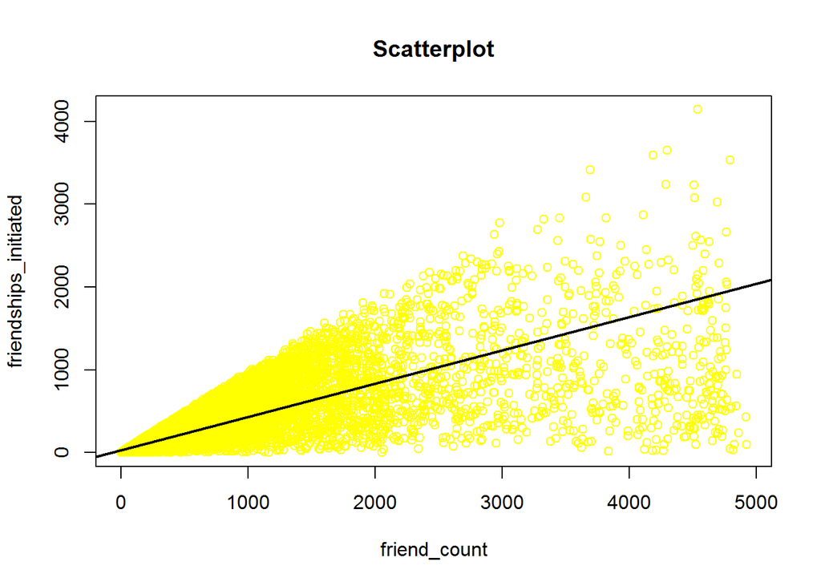

```r
abline(lreg, col = 9, lw = 2)
```